# QM 2025 Week 2: Probability and the Central Limit Theorem

Domantas Undzėnas Muhammad Muhammad David Grundmanns

September 11 | 12, 2025

## Today we will learn

0. How to work with **RMarkdown**.
1. How to look at **Probability Distributions in R**.
   1. Discrete Probability Distributions.
   2. Continuous Probability Distributions.
2. What the **Central Limit Theorem** is.

## RMarkdown revisited

You have already started getting yourself acquainted with `R Markdown` while working on the first assignment in `R Markdown`. Now it’s time to learn a bit more about it.

When you click the **Knit** or **Preview** button a document will be generated that includes both content as well as the output of any embedded R code chunks within the document. An R code chunk is anything that goes between `` ```{r} ... ``` ``. Additionally, you can name code chunks like this: `` ```{r name-here} ... ``` ``.

You can embed an R code chunk by typing it out or with a shortcut in RStudio (Mac: `Cmd+Alt+I`, Windows/Linux: `Ctrl+Alt+I`).

Here is a code chunk for you:

```r
# The first line sets an option for the final document that can be produced from
# the .Rmd file. Don't worry about it.
knitr::opts_chunk$set(
  echo = TRUE, # show results
  collapse = TRUE # not interrupt chunks
)

# The next bit (lines 56-75) is quite powerful and useful.
# First you define which packages you need for your analysis and assign it to
# the p_needed object.
p_needed <-
  c("viridis","ggplot2")

# Now you check which packages are already installed on your computer.
# The function installed.packages() returns a vector with all the installed
# packages.
packages <- rownames(installed.packages())
# Then you check which of the packages you need are not installed on your
# computer yet. Essentially you compare the vector p_needed with the vector
# packages. The result of this comparison is assigned to p_to_install.
p_to_install <- p_needed[!(p_needed %in% packages)]
# If at least one element is in p_to_install you then install those missing
# packages.
if (length(p_to_install) > 0) {
  install.packages(p_to_install)
}
# Now that all packages are installed on the computer, you can load them for
# this project. Additionally, the expression returns whether the packages were
# successfully loaded.
sapply(p_needed, require, character.only = TRUE)
```

```
## viridis ggplot2
##    TRUE    TRUE
```

### Chunk Options

Chunk output in your final document can be customized with knitr options, arguments set in the `{}` of a chunk header. Here are some useful arguments:

- `include = FALSE` prevents code and results from appearing in the finished file. R Markdown still runs the code in the chunk, and the results can be used by other chunks.
- `echo = FALSE` prevents code, but not the results from appearing in the finished file. This is a useful way to embed figures.
- `message = FALSE` prevents messages that are generated by code from appearing in the finished file.
- `warning = FALSE` prevents warnings that are generated by code from appearing in the finished file.
- `fig.cap = "..."` adds a caption to graphical results.

See the [R Markdown Reference Guide](https://artsci.usu.edu/math-stats/amlc/files/r-studio-reference-sheets-compilation.pdf) for a complete list of knitr chunk options.

### Text formatting options

Markdown also provides an easy way to format the text in your document. Here are some basics:

- *This text is italic*
- **This text is bold**
- `This is code`
- [This is a link to the R Markdown homepage](https://rmarkdown.rstudio.com)

For more formatting options, we recommend the [R Markdown Cheat Sheet](https://raw.githubusercontent.com/rstudio/cheatsheets/master/rmarkdown.pdf).

## Probability Distributions

All common probability functions are defined in R already. To call them you have to combine a prefix and the distribution name.

The prefixes you can use are d, p, q and r. When to use which prefix?

1. Use **d** when you know x and want to know the density at that point.
   - The result is a point of the probability mass/density function.
   - If you put in a range of x values you will get the **PDF/PMF** of the distribution.
2. Use **p** when you know q and want to know the probability up to that point.
   - The result is a point on the cumulative distribution function or the area under the probability density function.
   - If you put in a range of values you will get the **CDF** of the distribution.
3. Use **q** when you know the area p and want to know the x value
   - This is exactly the opposite of p.
4. Use **r** if you want random numbers drawn from a distribution.
   - The result is a sample from a distribution.
5. The distribution names are:
   - `binom` for the Binomial distribution
   - `norm` for the Normal distribution
   - `unif` for the Uniform distribution

For each of the distributions, you need to specify different parameters!

### Overview of R functions

Visually, you can see what each of these functions does on these plots:

#### Discrete Distribution

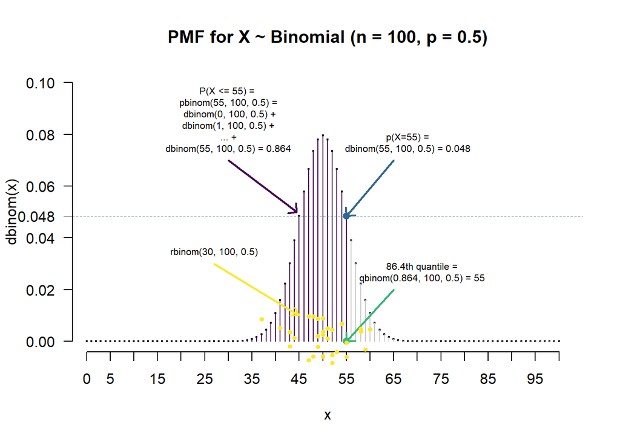

#### Continuous Distribution

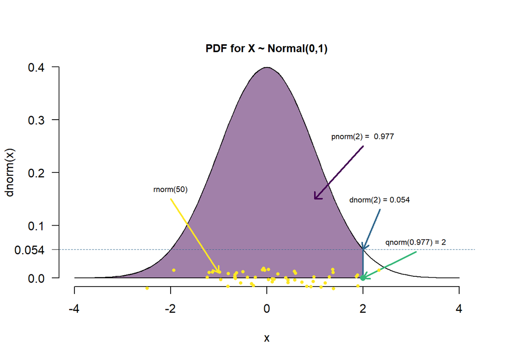

### Discrete Probability Distributions

Let’s start with Discrete Probability Distributions. Can you think of examples of Discrete Probability Distributions?

- Coin flip (multiple times)
- Number of votes obtained
- Number of members in a household
- Gender of a random person

#### The Bernoulli Distribution

The Bernoulli distribution is the simplest Discrete Probability Distribution. The Bernoulli distribution is a special case of the binomial distribution. It is a Binomial distribution with size 1. Thus, it is ideal for modeling **one-time** yes/no (success/failure) events.

```r
dbinom(x = 1, size = 1, prob = 0.8)  # What does the result tell us?
## [1] 0.8

dbinom(x = 0, size = 1, prob = 0.8)  # What does the result tell us?
## [1] 0.2
```

- `x` = number of successes (e.g. passing an exam)
- `size` = number of trials (1 coin flip)
- `prop` = probability of ‘success’ (e.g. probability of passing an exam)

The best example is **one** coin flip (or one voter voting yes/no, a person being either a woman/man). Let’s simulate one simple coin toss:

```r
rbinom(n = 1, size = 1, prob = 0.5)
## [1] 1
```

Ok, we could have done this with a real coin. Let’s toss one coin 1000 times. Any volunteers?

Luckily, R can simulate this more quickly.

```r
trial1 <- rbinom(n = 1000, size = 1, prob = 0.5)
```

- `n` = number of observations (i.e. how many coin flips we want to observe)

And now we want to see how successful we were:

```r
table(trial1)
## trial1
##   0   1
## 484 516
```

#### The Binominal Distribution

We get a binomial distribution if we – like in the lecture example – toss a coin twice. What are the possible outcomes, the so-called sample space?

- **Sample space**: {HH, HT, TH, TT}
- What is the probability of observing exactly 0 (1, 2) heads (successes)?

```r
dbinom(x = c(0, 1, 2),
       size = 2,
       prob = 0.5)
## [1] 0.25 0.50 0.25
```

- What is the probability of observing 0 or 1 heads (successes)?

```r
pbinom(1, 2, 0.5)
## [1] 0.75
```

- What is the probability of more than 1 head (successes)?

```r
1 - pbinom(1, 2, 0.5)
## [1] 0.25

# or:

pbinom(1, 2, 0.5, lower.tail = F)
## [1] 0.25
```

#### Example I: Coin Flips

We talked about probability in a frequentist understanding. Let’s check if repeating this experiment 1,000 times gives us the values we would expect.

Out of 1000 flips, you would expect 250 HH, 500 HT TH, and 250 TT.

```r
ex_trial <- rbinom(n = 1000, size = 2, prob = 0.5)
table(ex_trial)
## ex_trial
##   0   1   2
## 245 488 267
```

#### The PMF and CDF of a Binomial

Let’s plot the binomial probability mass function to get a better understanding.

##### Base R

We start by creating an x-axis and an empty plot.

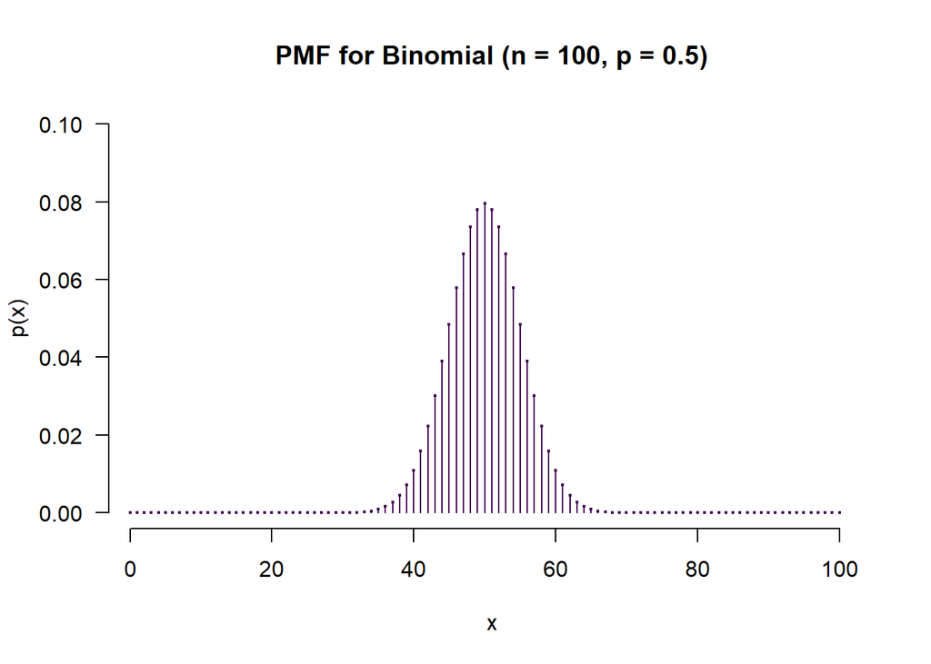

```r
# First, we need an x-axis
x_values <- 0:100

# Now we produce an empty plot.
plot(
  x = x_values,
  ylim = c(0, 0.1), # With ylim you can adjust the limits of the y-axis.
  type = "n",       # type "n" produces an empty plot window.
  main = "PMF for Binomial (n = 100, p = 0.5)",
  xlab = "x",
  ylab = "p(x)",
  las = 1,
  frame = F
  )

# Let's add the points.
points(x_values,
       dbinom(x_values, size = 100, p = 0.5),
       cex = 0.3,
       pch = 19,
       col = viridis(1)
       )

# And those lines we know from the lecture.
segments(x0 = x_values,
         y0 = 0,
         x1 = x_values,
         y1 = dbinom(x_values, size = 100, p = 0.5),
         col = viridis(1)
         )
```

> **Question: Why should we not use a line to connect the points?**

$\Rightarrow$ … because the outcome space is discrete, i.e. there is nothing like 2.5 heads out of a given number of coin flips.

What does the cumulative distribution function of the same Binomial look like?

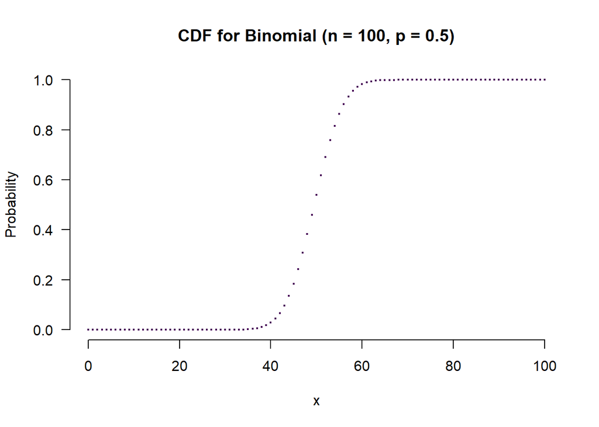

```r
plot(x = x_values,
     y = pbinom(x_values, size = 100, p = 0.5),
     type = "p",
     main = "CDF for Binomial (n = 100, p = 0.5)",
     xlab = "x",
     ylab = "Probability",
     bty = "n",
     las = 1,
     pch = 19,
     cex = 0.3,
     col = viridis(1),
     frame = F
     )
```

##### ggplot2

`ggplot2` is a very widely used package for visualization in the R community. We will be providing you with code using this package in addition to the code with built-in functions of R.

First, a few words about `ggplot2`. When working with this package, we think about images as being constructed from layers: the *data*-level, the mapping *aesthetics* level, and the *geom* level. These are the essential, but there are many more:

- *Data:* your data frame
- *Aesthetic mapping:* how data (variables) become plot attributes (axes, color, sizes)
- *Geoms:* geometric representations of data (points, lines, bars)
- *Scales:* modifying the mapping from data to plot (customizing axes, colors, sizes)
- *Facets:* sub-panels in the plot
- *Coordinates:* features of the coordinate system (orientation…)

If you want an overview of the different types of plots you can make with `ggplot2`, you can look at them [here](https://r-graph-gallery.com/). With the `ggplot2`package, it is most effective to work with datasets. So we’ll start by putting all of our vectors into a `data.frame` object.

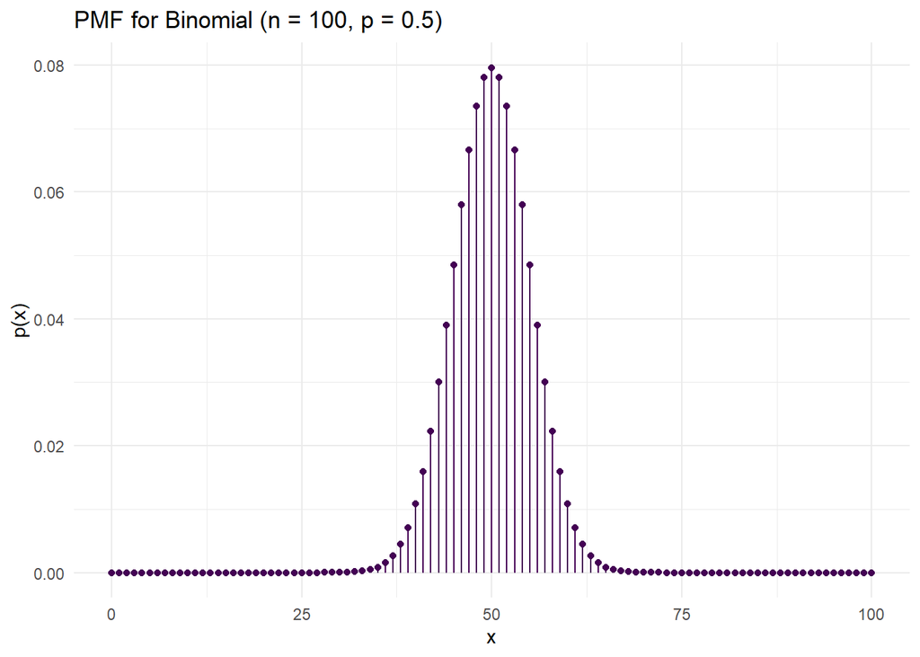

```r
library(ggplot2)

# create a dataset
binom_data <- data.frame(x = x_values,
                         density = dbinom(x_values, size = 100, p = 0.5))

# plot
ggplot( # empty plot for our data
  data = binom_data, # data used for plotting
  mapping = aes(x = x, y = density) # axes
) +
  geom_point(color = viridis(1)) + # add points
  geom_segment(aes( # add lines
    x = x, xend = x, # how thick the lines will be
    y = 0, yend = density # how long the lines will be
  ),
  color = viridis(1) # color the lines
  ) +
  theme_minimal() + # change the appearance
  labs(
    title = "PMF for Binomial (n = 100, p = 0.5)",
    y = "p(x)"
  )
```

> **Question: Why should we not use a line to connect the points?**

$\Rightarrow$ … because the outcome space is discrete, i.e. there is nothing like 2.5 heads out of a given number of coin flips.

What does the cumulative distribution function of the same Binomial look like?

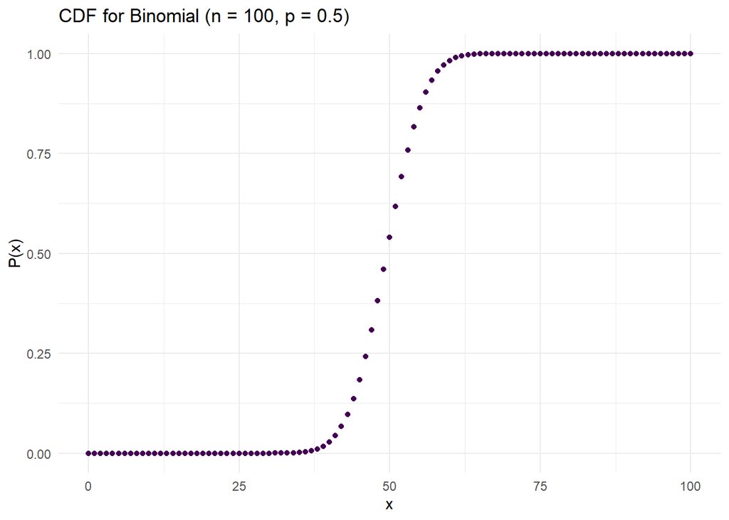

```r
# Add a new column to our dataset

binom_data$CDF <- pbinom(x_values, size = 100, p = 0.5)

ggplot(
  data = binom_data, # data used for plotting
  mapping = aes(x = x, y = CDF) # axes
) +
  geom_point(color = viridis(1)) + # add points
  theme_minimal() + # change the appearance
  labs(
    title = "CDF for Binomial (n = 100, p = 0.5)",
    y = "P(x)"
  )
```

#### Example II: Airline Reservations

A flight has 100 available seats, but the airline accepts 120 reservations (overbooking).

The probability of each person showing up is 0.85.

Now the airline wants to know the probability that more than 100 people show up.

- Remember the binomial process:
  - n independent trials
  - only two possible outcomes (show up/don’t show up)
  - success probability remains constant

We want to know:

$Pr(X>100)$.

This is $Pr(X=101)+Pr(X=102) +...Pr(X=120)$ (equal to $1-Pr(X\leq100)$.

1. What is the probability that more than 100 people show up?

```r
# Answer to a):
1 - pbinom(q = 100, size = 120, p = 0.85)
## [1] 0.6586167
```

2. Plot the cumulative distribution function of the problem.

##### Base R

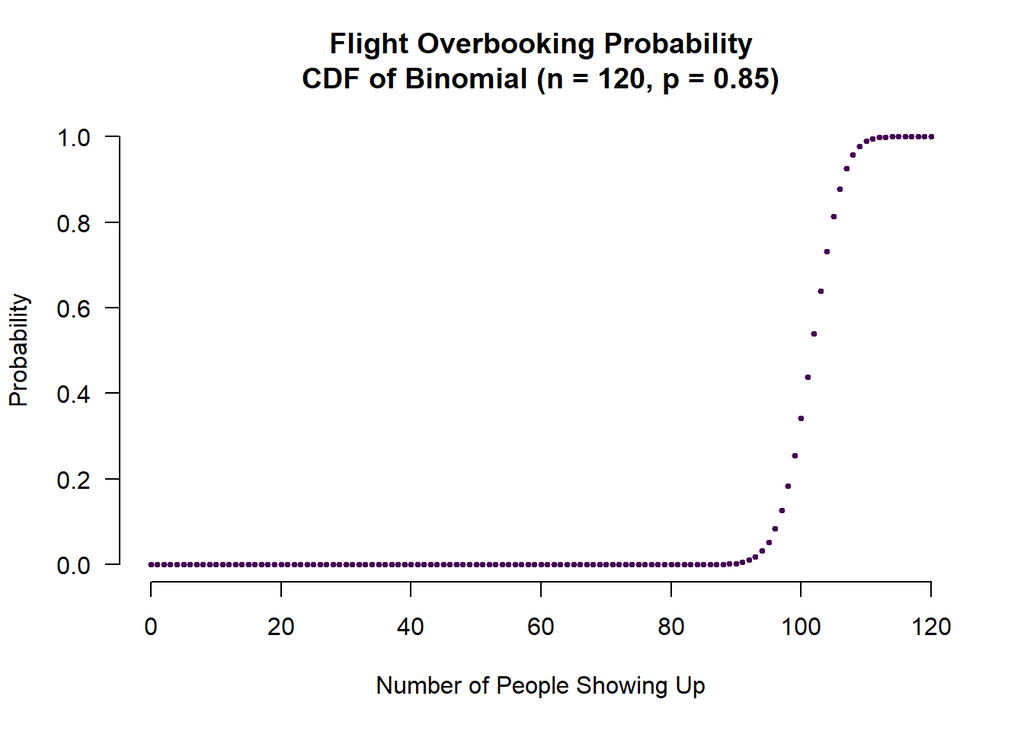

```r
# Answer to b):
passengers  <- 0:120 # for x-axis

plot(x = passengers,
     y = pbinom(q = passengers, size = 120, p = 0.85),
     bty = "n",
     las = 1,
     pch = 19,
     xlab = "Number of People Showing Up",
     ylab = "Probability",
     main = "Flight Overbooking Probability\nCDF of Binomial (n = 120, p = 0.85)",
     cex = 0.5,
     col = viridis(1),
     frame = F
     )
```

##### ggplot2

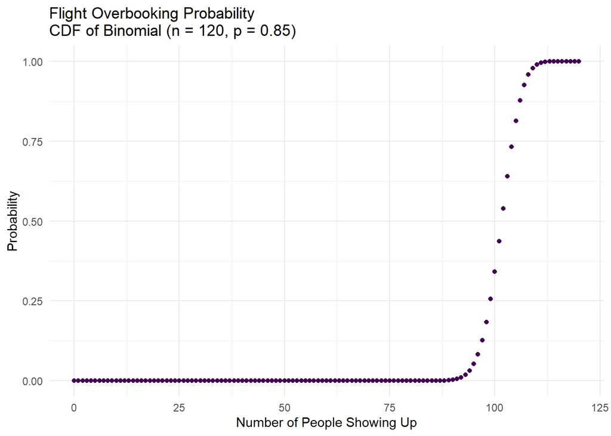

```r
# Answer to b):

# create a dataframe
airline_data <- data.frame(x = 0:120,
                           CDF = pbinom(q = 0:120, size = 120, p = 0.85))
# plot
ggplot(data = airline_data,  # data used for plotting
       mapping = aes(x = x, y = CDF)) +
  geom_point(color = viridis(1)) + # add points
  theme_minimal() + # change the appearance
  labs(x = "Number of People Showing Up",
       y = "Probability",
       title = "Flight Overbooking Probability\nCDF of Binomial (n = 120, p = 0.85)")
```

3. What is the probability of more than 100 people showing up if the airline limits overbooking to 110?

```r
# Answer to c):
1 - pbinom(q = 100, size = 110, p = 0.85)
## [1] 0.02442528
```

### Continuous Probability Distributions

We will be often looking at normal distributions. The most common normal distribution is the standard normal distribution.

> **What do you know about the standard normal distribution?**

Let’s go through those prefixes for the normal distribution again. If you want to know the probability that $x < 1.96$, use $p$:

```r
pnorm(q = 1.96, mean = 0, sd = 1)
## [1] 0.9750021
```

Conversely, if you want to know the probability that $x > 1.96$, use:

```r
1 - pnorm(q = 1.96, mean = 0, sd = 1)
## [1] 0.0249979
```

If you want to know at what value of $x$ do 30% of the data lie, use $q$:

```r
qnorm(p = 0.3, mean = 0, sd = 1)
## [1] -0.5244005
```

If you want to generate some random numbers of the normal distribution use $r$:

```r
rnorm(n = 20, mean = 0, sd = 1)
##  [1] -0.815590270 -0.097979107  0.100712692  0.003585345  0.105667658
##  [6] -1.664508299 -1.461838831 -0.952527422  1.185694648 -0.219893638
## [11] -1.406961165 -1.610807952  1.623569521 -0.024776263 -0.650781069
## [16]  1.371674042  0.283925967 -1.739904862  0.377618829  0.818553663
```

It is a good idea to plot those distributions (since `R` can draw better than me):

#### Base R

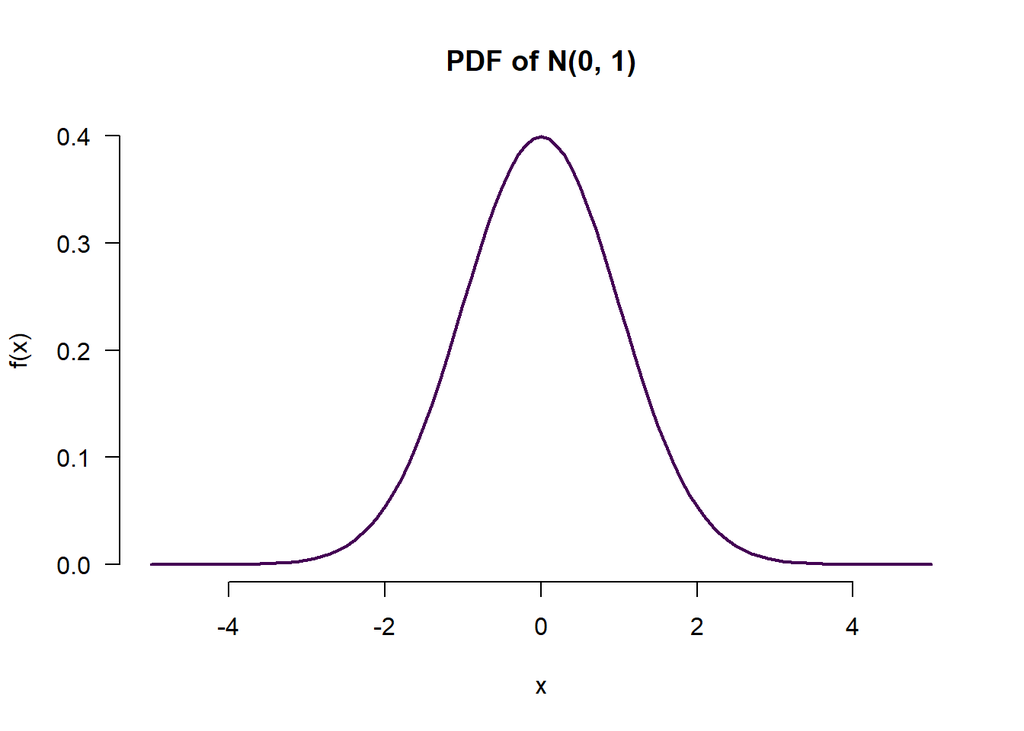

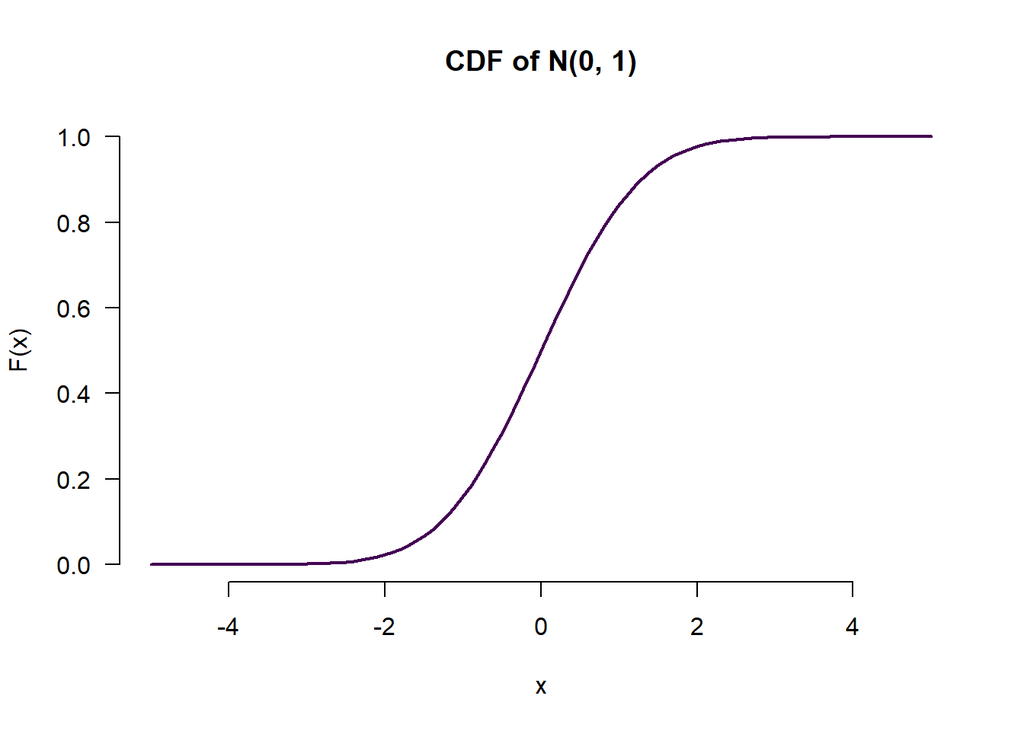

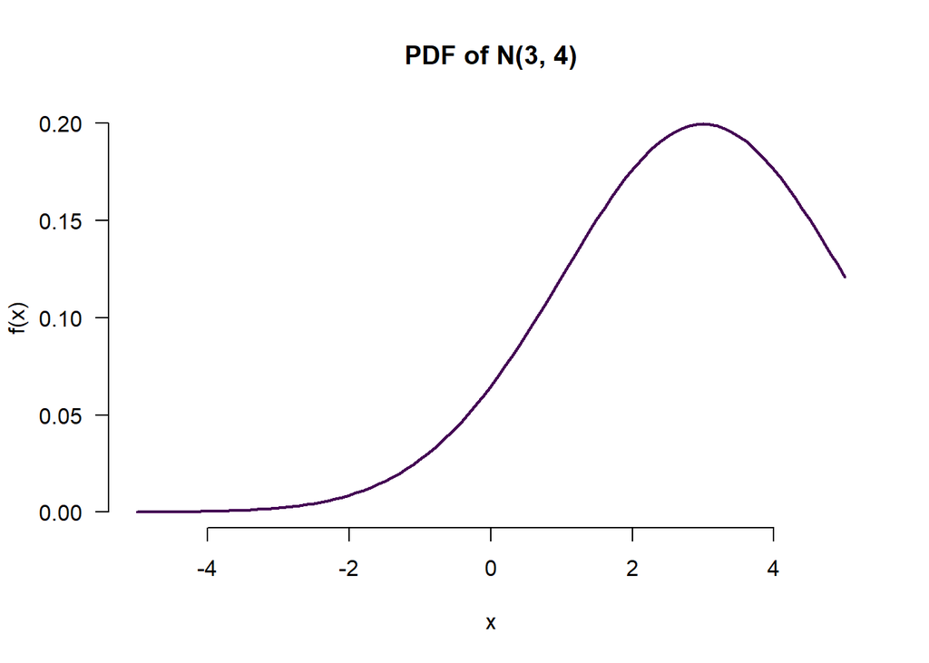

```r
x_values <- seq(from = -5, to = 5, by = 0.1)

plot(x = x_values,
     y = dnorm(x_values),
     bty = "n",
     las = 1,
     type = "l",
     col = viridis(1),
     lwd = 2,
     main = "PDF of N(0, 1)",
     ylab = "f(x)",
     xlab = "x"
     )

plot(x = x_values,
     y = pnorm(x_values),
     bty = "n",
     las = 1,
     type = "l",
     col = viridis(1),
     lwd = 2,
     main = "CDF of N(0, 1)",
     ylab = "F(x)",
     xlab = "x"
     )

# What if we have a different mean and sd?
plot(x = x_values,
     y = dnorm(x_values, mean = 3, sd = 2),
     bty = "n",
     las = 1,
     type = "l",
     col = viridis(1),
     lwd = 2,
     main = "PDF of N(3, 4)",
     ylab = "f(x)",
     xlab = "x"
     )
```

#### ggplot2

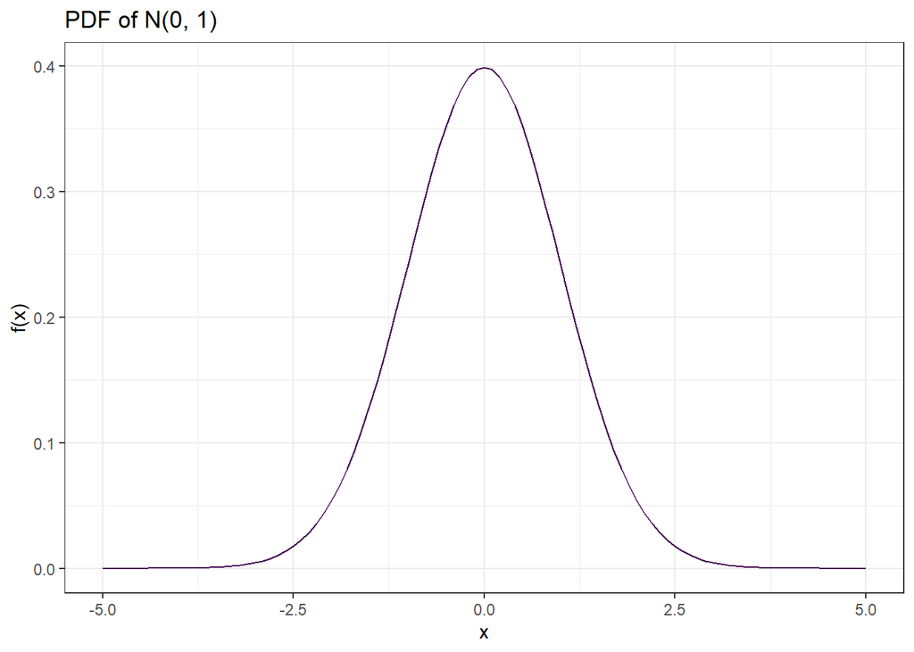

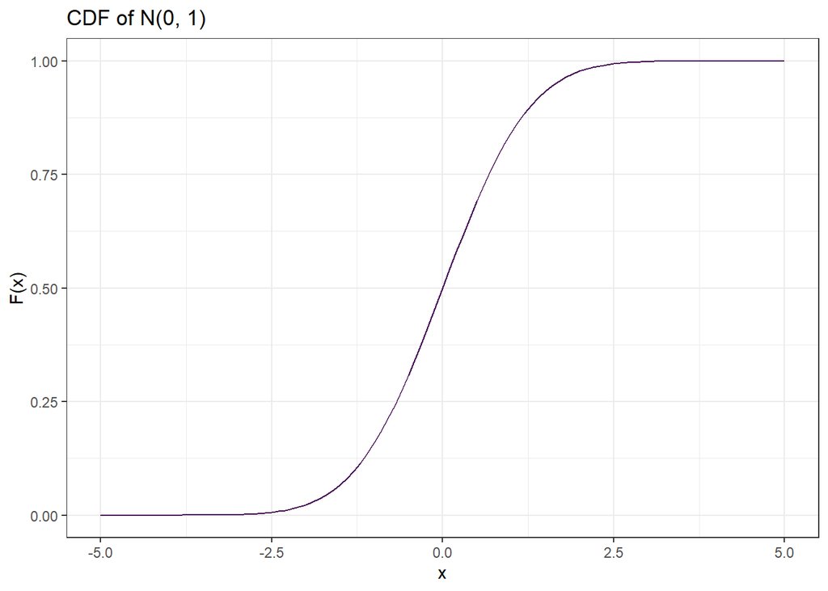

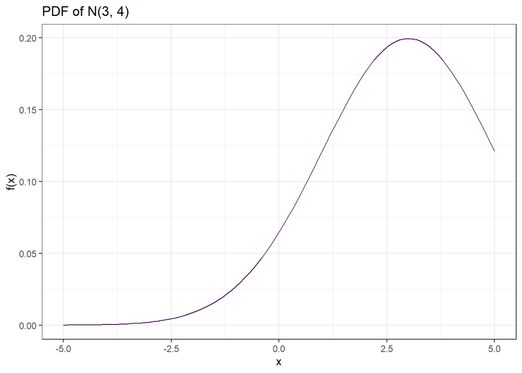

```r
x_values <- seq(from = -5, to = 5, by = 0.1)

# ggplot can also work without datasets

ggplot() + # this creates an empty plot
  geom_line(aes(x = x_values, y = dnorm(x_values)),
            color = viridis(1)) +
  labs(title = "PDF of N(0, 1)",
       y = "f(x)",
       x = "x") +
  theme_bw()

ggplot() + # this creates an empty plot
  geom_line(aes(x = x_values, y = pnorm(x_values)),
            color = viridis(1)) +
  labs(title = "CDF of N(0, 1)",
       y = "F(x)",
       x = "x") +
  theme_bw()

ggplot() + # this creates an empty plot
  geom_line(aes(x = x_values, y = dnorm(x_values, mean = 3, sd = 2)),
            color = viridis(1)) +
  labs(title = "PDF of N(3, 4)",
       y = "f(x)",
       x = "x") +
  theme_bw()
```

#### Example III: Normal Approximation of the Binomial

We saw that the binomial distribution can be approximated by the normal. Let’s calculate the airplane reservation example using a normal distribution.

First, we have to think about the underlying distribution. Using the central limit theorem, we can translate the binomial process into a normal distribution. 0.85 percent of the people are expected to show up, thus the mean can be calculated by $E(X)=n*p$. The variance can be calculated using $Var(X)=n*p*(1-p)$ (see slide 13).

Let’s calculate the mean and the variance of the normal distribution:

```r
n <- 120
p <- 0.85
mean <- n * p
sd <- sqrt((n * p * (1 - p)))  # Why do we have to use the square root?
```

Let’s solve an example with the normal distribution:

1. What is the probability that more than 100 people will show up if we accept 120 reservations?
2. Plot the normal distribution.
3. Compare your result to the Binomial process from above.

##### Base R

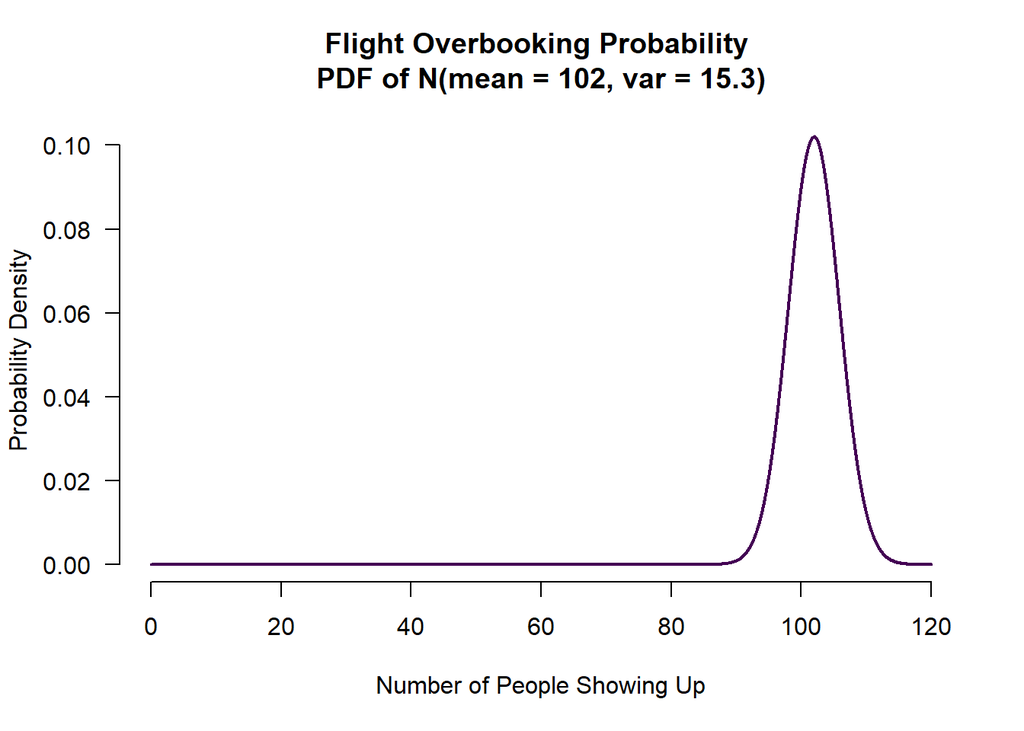

```r
# part a)
1 - pnorm(q = 100, mean = mean, sd = sd)
## [1] 0.695433

# part b)
passengers <- seq(from = 0, to = 120, by = 0.01)
densities <- dnorm(passengers, mean = mean, sd = sd)

plot(
  x = passengers,
  y = densities,
  bty = "n",
  las = 1,
  col = viridis(1),
  xlab = "Number of People Showing Up",
  ylab = "Probability Density",
  type = "l",
  lwd = 2,
  cex = 2,
  main = "Flight Overbooking Probability \nPDF of N(mean = 102, var = 15.3)"
)
```

```r
# part c)
1 - pnorm(q = 100, mean = mean, sd = sd)
## [1] 0.695433
1 - pbinom(q = 100, size = n, prob = p)
## [1] 0.6586167
```

##### ggplot2

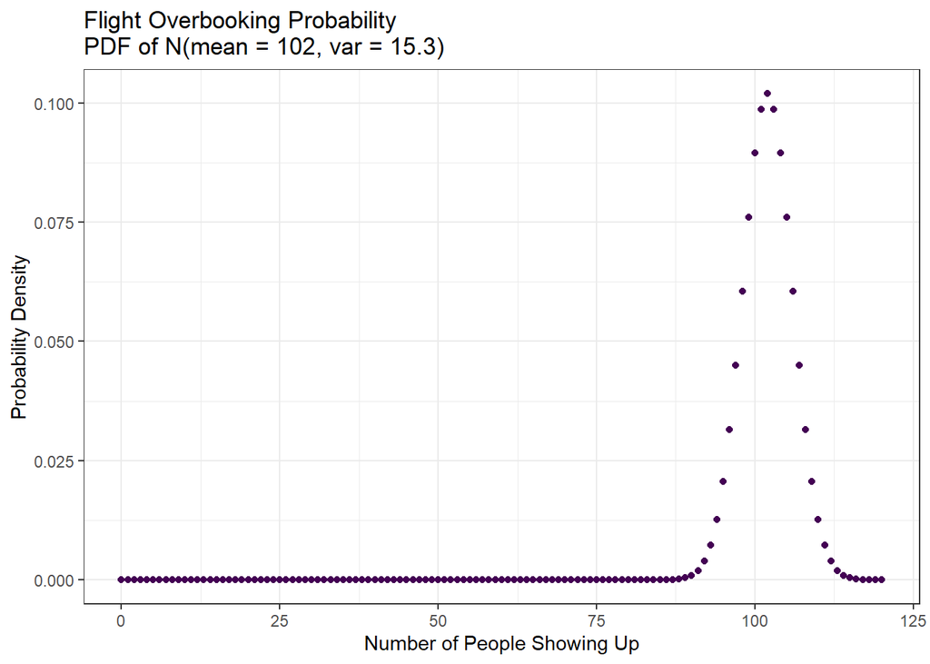

```r
# part a)
1 - pnorm(q = 100, mean = mean, sd = sd)
## [1] 0.695433

# part b)
# modify dataset from before
airline_data$CDF_normal <- dnorm(airline_data$x, mean = mean, sd = sd)

ggplot(airline_data,
       aes(x = x,
           y = CDF_normal)) +
  geom_point(color = viridis(1)) +
  labs(
    title = "Flight Overbooking Probability \nPDF of N(mean = 102, var = 15.3)",
    x = "Number of People Showing Up",
    y = "Probability Density"
  )  +
  theme_bw()
```

```r
# part c)
1 - pnorm(q = 100, mean = mean, sd = sd)
## [1] 0.695433
1 - pbinom(q = 100, size = n, prob = p)
## [1] 0.6586167
```

## Variable standardization

Sometimes we have variables on different scales or from different distributions that we want to compare. In order to compare results from these variables we can standardize them. In the literature, this is also called z-standardization. Essentially, we transform any continuous variable to have a mean of 0 and a standard deviation of 1. Just like a standard normal distribution! The formula for standardization is

$$z_i = \frac{x_i -
\bar{x}}{\sigma}$$

In a nutshell, we subtract the mean of our variable from each individual observation and divide that difference by the standard deviation of our variable. Let’s consider an example. We have two weightlifters at the gym, one woman – Sally – and one man – Jack. Sally can lift 90kg on the bench press, while Jack can lift 160kg. Who is stronger? Women and men have different distributions of how many kilograms they can lift, so it is unhelpful to compare raw numbers. This is where standardization comes in. Let’s consider that women lift on average 60kg with a standard deviation of 20kg. For men, the distribution has a mean of 120 kg with a standard deviation of 40kg.

```r
# Standardizing the lift strength for the Sally

sally_power <- (90-60)/20

# And now for Jack

jack_power <- (160-120)/40

# Who is stronger?

sally_power
## [1] 1.5

jack_power
## [1] 1
```

Sally has a higher standardized score, meaning that comparing her to the Women’s population, she is actually stronger than Jack when comparing him to the men’s population. Z-scores can be directly interpreted as how many standard deviations you are away from the population mean. In this case, Sally is 1.5 standard deviations stronger than the average woman and Jack is 1 standard deviation stronger than an average man. Both are pretty strong people, but Sally is stronger.

You can use the same logic when standardizing variables. Let’s generate a variable!

```r
# Creating a random variable

variable <- rnorm(100, mean = 200, sd = 700)

# Definitely not standardized!

mean(variable)
## [1] 137.1939

sd(variable)
## [1] 717.201

# So let's standardize it!

standard_variable <- (variable - mean(variable))/sd(variable)

# Now it is actually standardized

mean(standard_variable)
## [1] -1.55789e-17

sd(standard_variable)
## [1] 1
```

## Central Limit Theorem

Finally, we want to better understand the central limit theorem. Let’s generate a random population:

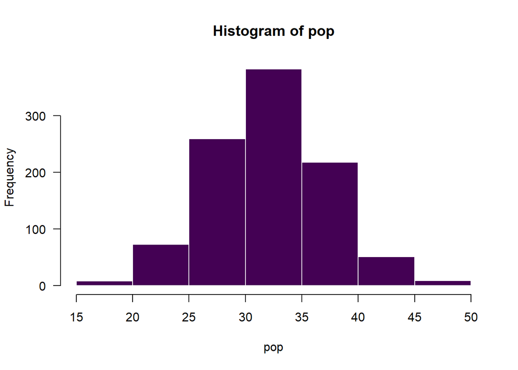

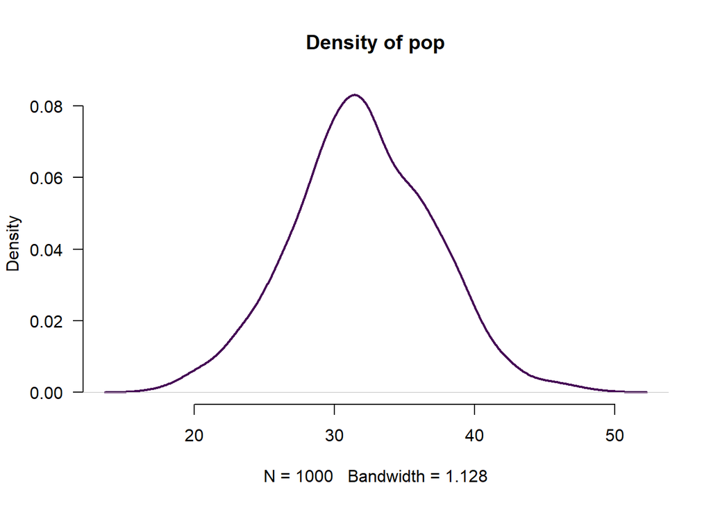

```r
pop <- rnorm(1000, mean = 32, sd = 5) # we know the "true" values
summary(pop)
##    Min. 1st Qu.  Median    Mean 3rd Qu.    Max.
##   17.00   28.83   31.86   32.03   35.52   48.90
var(pop)
## [1] 25.58795

hist(pop,
     bty = "n",
     las = 1,
     border = "white",
     col = viridis(1)
     )

plot(density(pop),
     bty = "n",
     las = 1,
     col = viridis(1),
     lwd = 2,
     main = "Density of pop"
     )

sample(pop, 200) # take a random sample of size 200 from the population
##   [1] 24.46281 31.65001 34.03873 34.89680 36.63006 37.63215 27.84667 29.95511
##   [9] 37.32131 33.35735 40.53311 26.70470 25.71468 37.62427 34.10192 41.15726
##  [17] 24.59584 29.21181 25.32013 34.57471 26.88578 29.24033 42.46032 32.42339
##  [25] 31.63318 32.62070 23.99361 28.98417 37.17179 30.09863 34.69746 37.20017
##  [33] 33.14588 34.53599 33.15643 38.10414 34.24069 43.45719 37.77537 22.28633
##  [41] 32.29076 25.89144 31.62472 31.28613 26.44421 36.06026 39.77458 29.61158
##  [49] 36.61242 35.23970 31.38313 40.08579 34.33169 42.48968 30.93048 34.69298
##  [57] 31.53774 30.63643 31.44588 24.14424 31.84833 35.25568 33.21773 31.12089
##  [65] 24.76095 35.74638 29.74485 31.98334 32.65329 35.99612 37.94366 32.01364
##  [73] 37.33529 28.05419 32.54763 30.35093 35.75365 35.01151 29.05661 33.86287
##  [81] 29.44333 34.59179 29.49287 25.71510 42.04163 26.15700 33.99689 38.28058
##  [89] 29.92210 38.77367 37.48543 27.93686 32.22639 24.93429 38.47756 34.57738
##  [97] 32.19437 24.65448 36.26669 30.37748 31.85250 26.55071 33.16003 28.11291
## [105] 33.82668 30.47246 36.04535 33.75388 28.95921 22.64793 18.75090 34.23237
## [113] 36.79176 36.38104 28.56516 42.03901 30.35516 37.67907 38.53541 21.66314
## [121] 31.36209 26.18104 26.54049 28.86311 30.60584 31.24304 26.44383 31.76908
## [129] 29.03295 23.43244 45.45658 32.17881 26.22530 32.16987 30.80590 38.27264
## [137] 27.42286 34.62371 33.64152 36.79285 36.47885 29.73992 29.12027 32.35600
## [145] 29.22909 36.53186 29.41215 40.40296 33.63893 36.91304 32.35237 40.03831
## [153] 27.56839 28.53647 22.27725 38.43144 26.16951 35.29803 34.22476 29.59782
## [161] 35.88632 26.96462 33.42798 35.52811 41.47251 30.17248 26.12526 32.98870
## [169] 37.16623 24.47018 32.19051 24.28813 29.65733 39.00289 34.34403 33.51471
## [177] 30.23638 36.82265 40.25312 33.60074 33.78121 28.20241 32.62079 30.66257
## [185] 39.26096 32.84961 23.55650 28.41520 29.05021 35.65850 32.00365 29.86928
## [193] 28.39499 29.19046 32.83471 30.04138 31.90846 35.37375 27.29662 41.50514
```

### CLT Trial 1: Sample Size = 100

Let’s take 100 samples with 100 persons in each sample. First, we create an empty vector - `trial1` - of length 100 to store the results:

```r
trial1 <- rep(NA, 100)
```

Now we have to do some programming. We create a *for loop* counting $i$ from 1 to 100. For each iteration the loop is saving the mean of our sample in the vector `trial1`.

```r
for (i in 1:100){
  trial1[i] <- mean(sample(pop, 100))
}

trial1
##   [1] 31.29813 31.84791 32.17541 32.59500 32.43002 32.56166 32.72750 31.25833
##   [9] 31.98740 32.01142 31.69877 32.71800 32.62155 32.29373 31.75672 31.70964
##  [17] 31.48085 32.16090 31.76314 31.88318 32.16012 32.31118 32.14285 31.58763
##  [25] 32.37142 32.35836 33.16741 31.79048 31.50380 31.51250 32.82137 31.55808
##  [33] 32.62846 31.78845 32.61802 32.09231 32.51018 32.30205 31.41915 31.55883
##  [41] 31.81971 32.78204 32.05935 32.84599 32.15937 31.56212 32.10391 32.37461
##  [49] 31.56293 32.20539 31.97649 32.40124 31.39937 31.44989 31.31516 32.23096
##  [57] 32.24144 32.39513 31.76770 32.47134 32.98492 32.16791 32.02050 32.04278
##  [65] 32.27957 31.60554 32.25676 31.54980 31.76803 31.85638 31.19206 31.86692
##  [73] 31.51355 31.86036 32.42765 31.86037 31.29063 31.56143 32.16916 31.37328
##  [81] 32.47056 31.25265 31.27405 32.04673 31.26969 32.18548 31.84046 32.08558
##  [89] 32.05919 32.52393 31.97035 32.13824 32.45936 31.72372 32.53703 32.35334
##  [97] 32.62331 31.37337 32.56771 32.17249
```

Let’s have a look at our *sampling distribution*:

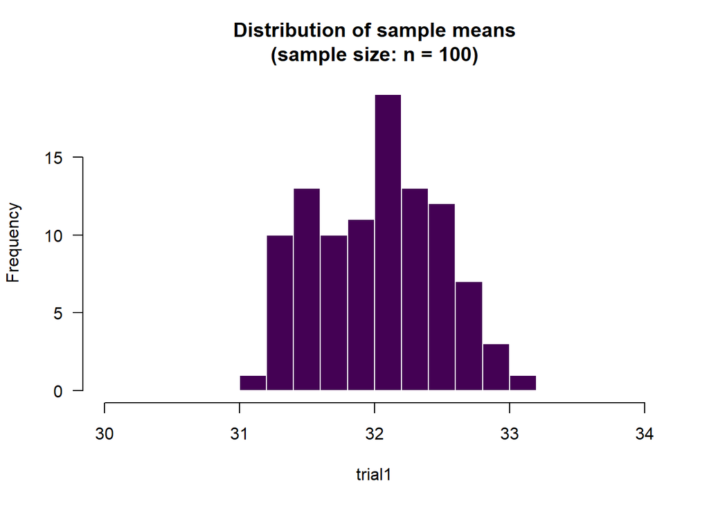

```r
hist(trial1,
     bty = "n",
     las = 1,
     border = "white",
     col = viridis(1),
     xlim = c(30, 34),
     main = "Distribution of sample means\n(sample size: n = 100)"
     )
```

```r
mean(trial1)
## [1] 32.02881
var(trial1)
## [1] 0.2091513
```

### CLT Trial 2: Sample Size = 400

We do it again. But this time we will take 100 samples with 400 people in each sample. It works just as above.

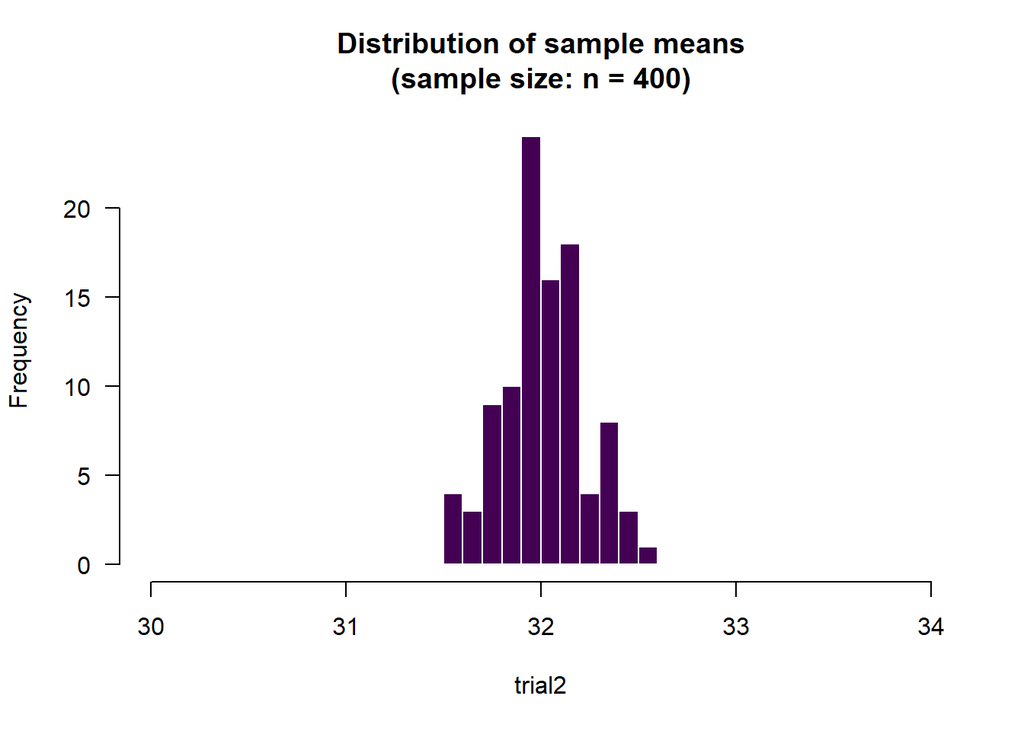

```r
trial2 <- rep(NA, 100)

for (i in 1:100){
  trial2[i] <- mean(sample(pop, 400))
}

hist(trial2,
     bty = "n",
     las = 1,
     border = "white",
     col = viridis(1),
     xlim = c(30, 34),
     main = "Distribution of sample means\n(sample size: n = 400)"
     )
```

```r
mean(trial2)
## [1] 32.0109
var(trial2)
## [1] 0.04376371
```

Does the variance of the sampling distribution behave according to $\frac{sd^2}{n}$?

The original standard deviation value was 5, so $\frac{25}{n}$ should be the variance of our sampling distribution!

```r
var(pop)/400
## [1] 0.06396989
```

In the lecture, we learned that the sampling distribution of the mean always approaches a normal distribution, regardless of the shape of the original distribution!

You don’t believe me? See for yourself.

Income, for example, is usually not really normally distributed. First, we generate some hypothetical income data.

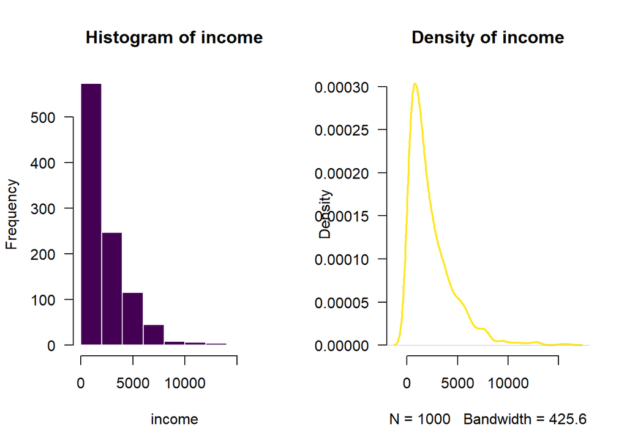

```r
income <- rgamma(1000, shape = 1.1, scale = 2000)
summary(income)
##      Min.   1st Qu.    Median      Mean   3rd Qu.      Max.
##     8.466   763.878  1630.598  2327.492  3286.612 16024.970
var(income)
## [1] 4893650

# Let's have a look.
par(mfrow = c(1, 2)) # two plots side-by-side (alternative to chunk arguments)
hist(income,
     bty = "n",
     las = 1,
     border = "white",
     col = viridis(2)[1]
     )

plot(density(income),
     bty = "n",
     las = 1,
     col = viridis(2)[2],
     lwd = 2,
     main = "Density of income"
     )
```

This is clearly a non-normal distribution. Now we want to get our sampling distribution of the mean again.

### CLT Trial 3: A non-normal population distribution

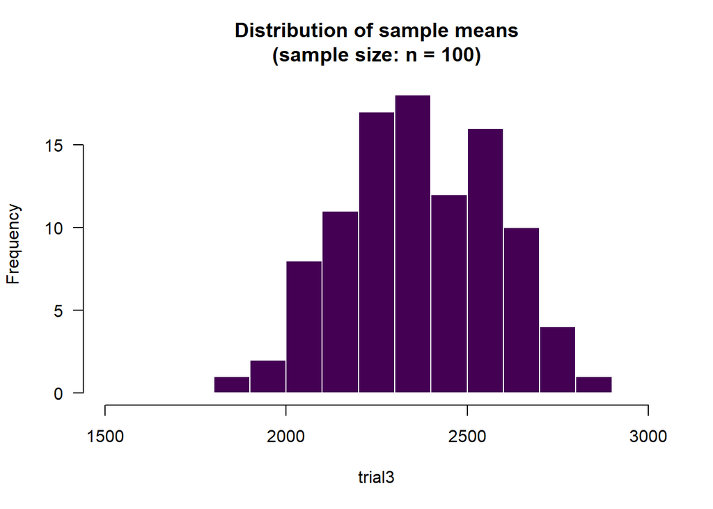

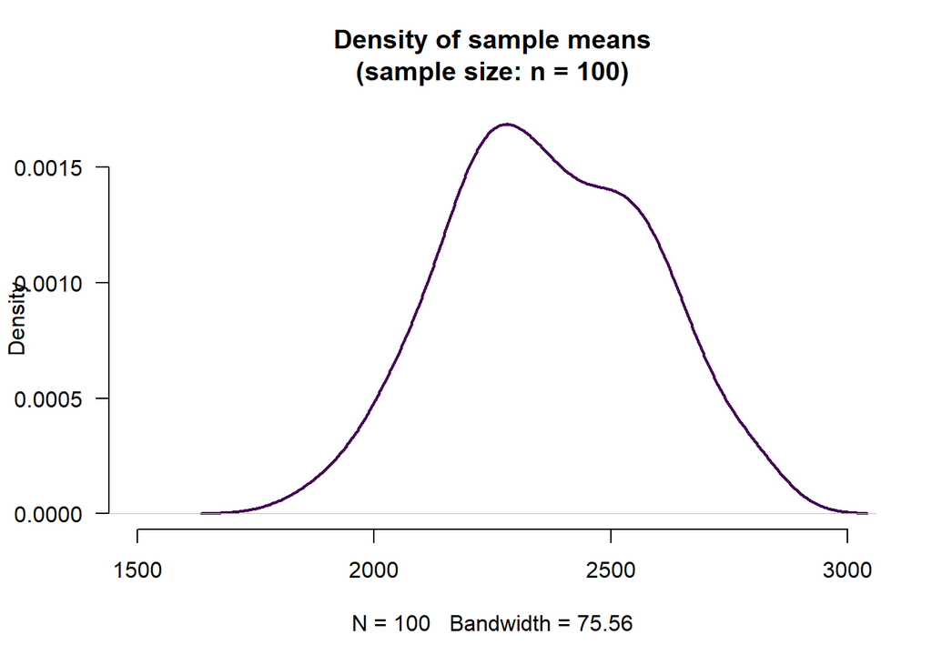

```r
trial3 <- rep(NA, 100)

for (i in 1:100){
  trial3[i] <- mean(sample(income, 100))
}

hist(trial3 ,
     bty = "n",
     las = 1,
     border = "white",
     col = viridis(1),
     xlim = c(1500, 3000),
     main = "Distribution of sample means\n(sample size: n = 100)"
     )

plot(density(trial3),
     bty = "n",
     las = 1,
     lwd = 2,
     col = viridis(1),
     xlim = c(1500, 3000),
     main = "Density of sample means\n(sample size: n = 100)"
     )

mean(trial3)
## [1] 2368.003
var(trial3)
## [1] 44472.11
```

### CLT Trial 4: A non-normal population distribution II

#### Base R

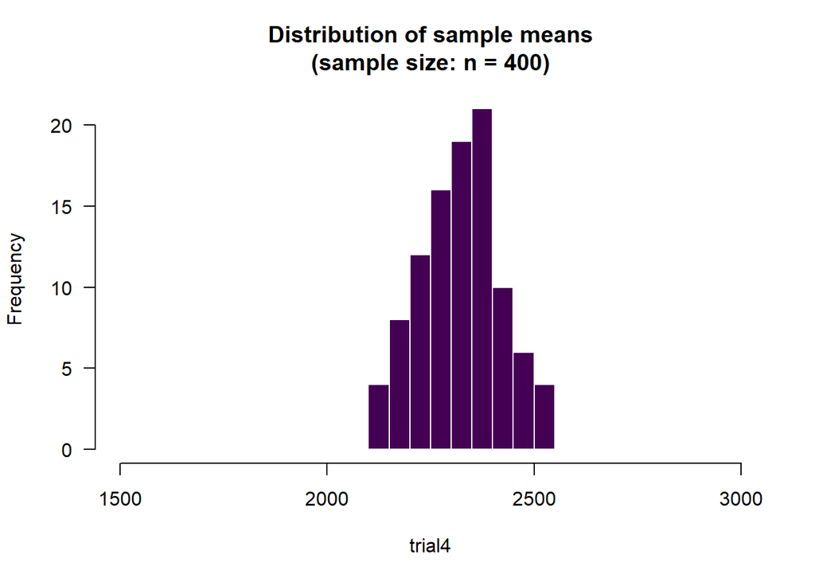

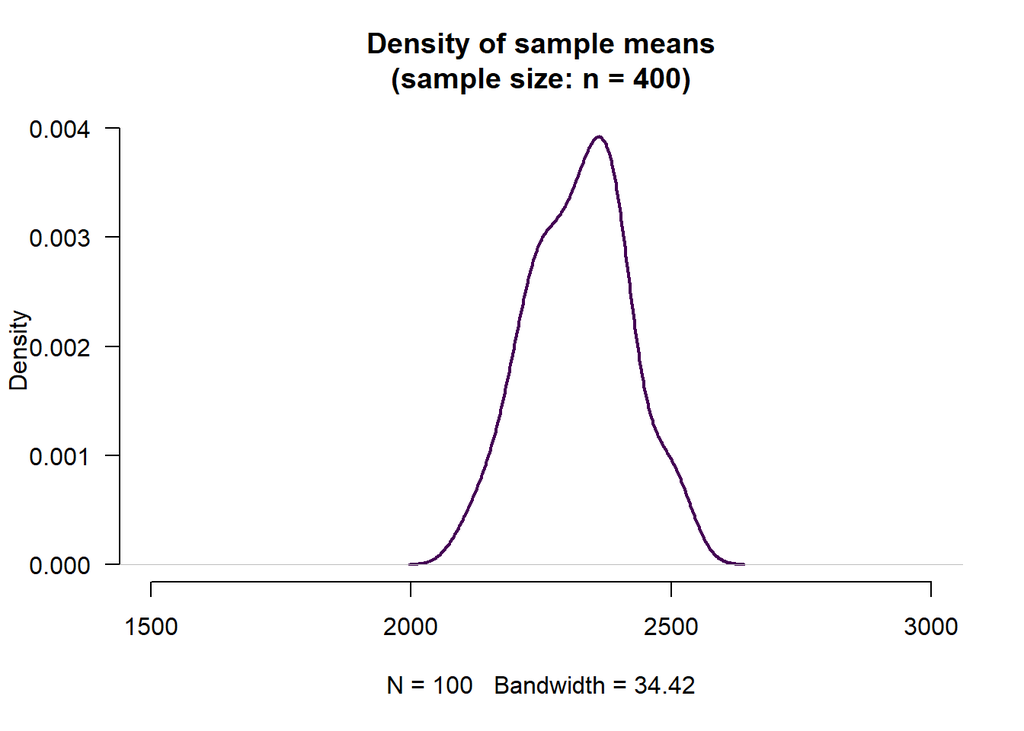

```r
trial4 <- rep(NA, 100)

for (i in 1:100){
  trial4[i] <- mean(sample(income, 400)) #this time, we sample 400 people
}

hist(trial4,
     bty = "n",
     las = 1,
     border = "white",
     col = viridis(1),
     xlim = c(1500, 3000),
     main = "Distribution of sample means\n(sample size: n = 400)"
     )

plot(density(trial4),
     bty = "n",
     las = 1,
     lwd = 2,
     col = viridis(1),
     xlim = c(1500, 3000),
     main = "Density of sample means\n(sample size: n = 400)"
     )

mean(trial4)
## [1] 2322.767
var(trial4)
## [1] 9227.273
```

#### ggplot2

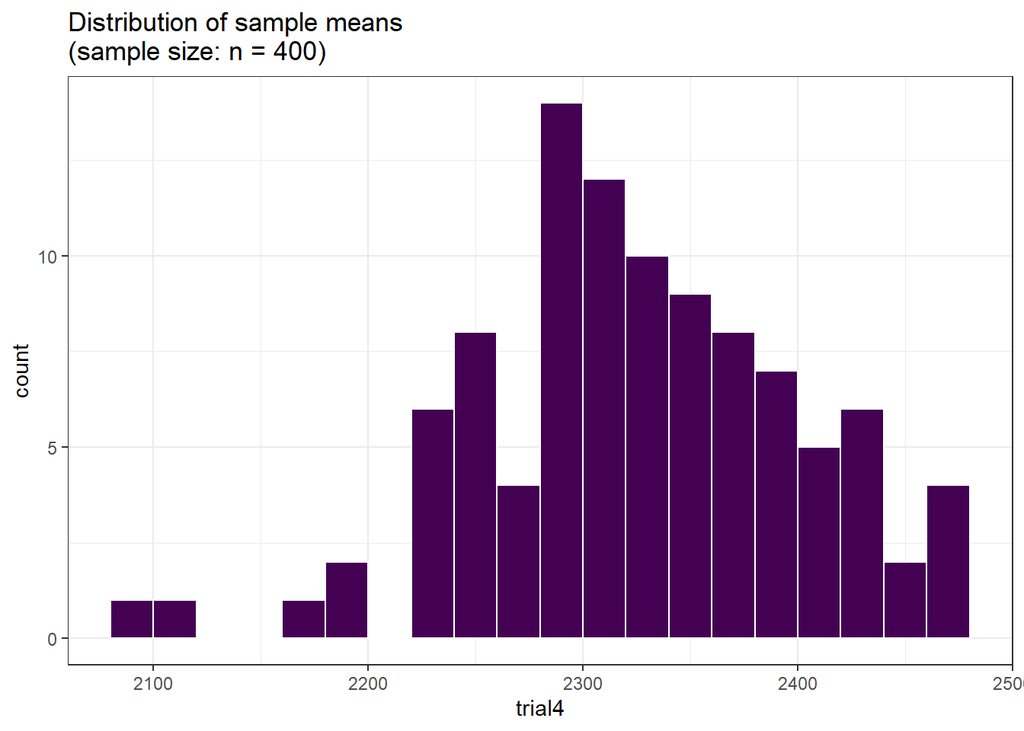

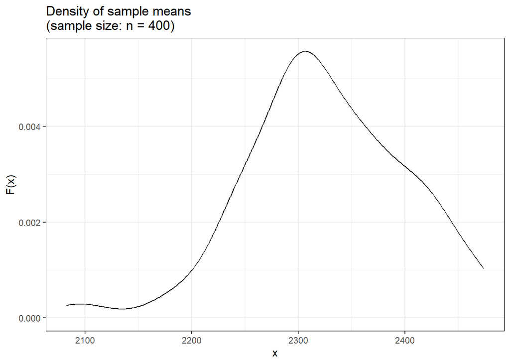

```r
trial4 <- rep(NA, 100)

for (i in 1:100){
  trial4[i] <- mean(sample(income, 400)) #this time, we sample 400 people
}

ggplot() +
  geom_histogram(aes(x = trial4),
                 boundary = 2200,
                 binwidth = 20,
                 color = "white",
                 fill = viridis(1)) +
  theme_bw() +
  labs(title = "Distribution of sample means\n(sample size: n = 400)")

ggplot() +
 geom_density(aes(trial4)) +
  labs(title = "Density of sample means\n(sample size: n = 400)",
       y = "F(x)",
       x = "x") +
  theme_bw()

mean(trial4)
## [1] 2325.409
var(trial4)
## [1] 5714.668
```

### Set Seeds!

Setting seeds is extremely helpful for the homework and replicability in general. To do so, use the following command: `set.seed()`.

```r
a <- rnorm(5)

b <- rnorm(5)

a == b
## [1] FALSE FALSE FALSE FALSE FALSE


set.seed(1234)
a <- rnorm(5)

set.seed(1234)
b <- rnorm(5)

a == b
## [1] TRUE TRUE TRUE TRUE TRUE
```

## Concluding remarks

Next, you find some exercises to check your knowledge.

## Exercises

### Exercise A: Airline reservations again

Now the airline also has a bigger plane.

The flight has 250 available seats, but the airline accepted 275 reservations (overbooking).

Since this is a long haul flight, the probability of each person showing up is a bit higher at 0.89.

Now the airline wants to know the probability that more than 250 people show up.

- Remember the binomial process:
  - n independent trials
  - only two possible outcomes (show up, don’t show up)
  - success probability remains constant

We want to know:

$Pr(X>250)$.

This is $Pr(X=251)+Pr(X=252) +...Pr(X=275)$ (equal to $1-Pr(X<=250)$.

1. What is the probability that more than 250 people show up?
2. Plot the cumulative distribution function of the problem.
3. What is the probability of more than 250 people showing up if the airline limits overbooking to 260?

```r
# Answer to a):

# Answer to b):
xaxis <-c(0:275) # for x-axis
plot(x = xaxis,
     y = # ??
     bty = "n",
     las = 1,
     pch = 19,
     xlab = "Number of people showing up",
     ylab = "Cumulative Distribution",
     main = "CDF of overbooking Binomial(n = 275, p = 0.89)",
     cex = 0.5,
     col = viridis(1),
     frame = F
     )

# Answer to c):
```

### Exercise B: Airline reservations and the Normal Approximation

We saw that the binomial distribution can be approximated by the normal. Let’s calculate the airplane reservation example using a normal distribution.

First, we have to think about the underlying distribution. Using the central limit theorem, we can translate the binomial process into a normal distribution. 0.89 percent of the people are expected to show up, thus the mean can be calculated by $E(X)=n*p$. The variance can be calculated using $Var(X)=n*p*(1-p)$ (see slide 13).

Let’s calculate the mean and the standard deviation of the normal distribution:

```r
# n <-
# p <-

# mean <-
# sd <-

# mean
# sd
```

Let’s solve an example with the normal distribution:

1. What is the probability that more than 250 people will show up if we make 275 reservations?
2. Plot the normal distribution.
3. Compare your result to the Binomial process from above.

```r
# answer to a)

# answer to b)
xaxis <- seq(0, 275, 0.01)
plot(x = xaxis,
     y = # ??,
     bty = "n",
     las = 1,
     col = viridis(1),
     xlab = "% of People showing up",
     ylab = "Probability Density",
     type = "l",
     lwd = 2,
     cex = 2,
     main = "PDF of overbooking example N(244.75, 5.19)"
     )

# answer to c)
```